# Time Series HW 3

Justin Gomez and Andrea Mack

**Disclaimer:** Justin and Andrea are NEW partners, we have never worked together in one of Dr. Greenwood’s classes on an assignment until now.

```r
require(xtable)
require(effects)
require(car)#Anova
require(pander)#tables
```

## HW 3

You can alone or in pairs that may or may not be people you worked with before. You can discuss it with old partners but should try work as much as possible with new collaborators. 5% bonus if you find someone completely new to work with - that you did not work with on first two assignments.

I mentioned de-seasonalizing of time series, where the seasonal variation is removed from the series to highlight variation at either higher or lower frequencies. There are a variety of techniques for doing this but the simplest is to just subtract the mean for each month from the observations. And the easiest way to find that is using `lm(y~month,data=...)`.

1. For the Bozeman temperature data from HW 1 and 2, estimate a model with month only, subtract its fitted values from the responses (or just extract residuals). Plot the residuals vs the fractional `Year` variable and compare the plot of this result to the plot of the original time series.

*Comparing the plot of the residuals and the fractional year to the plot of the max monthly temperatures and the fractional year, we can see that the noise has been reduced in the residuals plot, and a slight positive linear trend is observed. Unusual points are also more apparent in the plot of the residuals as they are slightly set apart from the bulk of the data, compared to the plot of the max monthly themperatures with so much noise that extreme points seem to fall in with the rest of the data.*

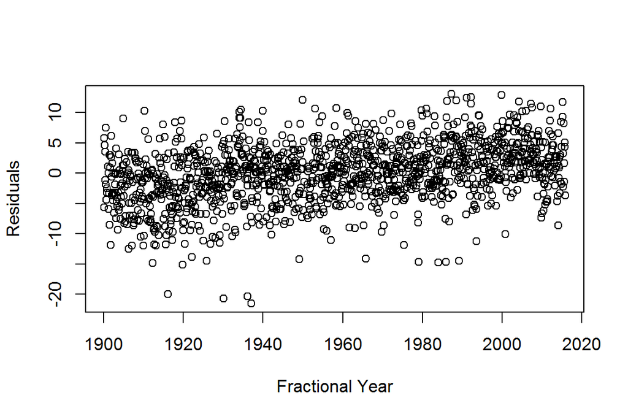

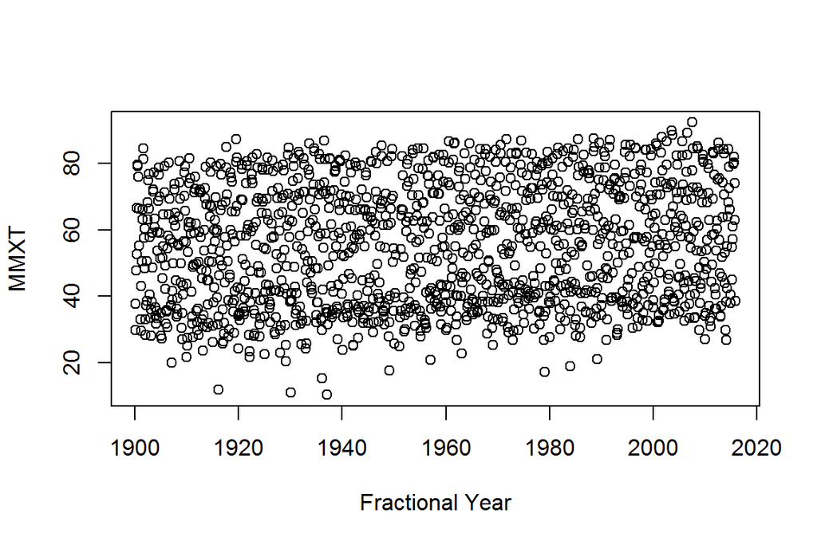

2. In the de-seasonalized Bozeman temperature data set, re-assess evidence for the linear trend. Compare the result (test statistic, degrees of freedom and size of p-value) of just fitting a linear time trend in these de-seasonalized responses to the result from our original model with a linear year component and a month adjustment (not the quadratic trend model).

*The degrees of freedom change when we are estimating more parameters, and the F statistic changes as well. However, both models resulted in pvalues that were very, very small.*

| model | test stat | df | pvalue |
| --- | --- | --- | --- |
| resid $\sim$ year | Fstat=195.9 | $Fstat_{1,1371}$ | <0.00001 |
| temp $\sim$ year+monthf | Fstat=1628 | $Fstat_{12,1361}$ | <0.00001 |

```r
require(pander)
lm2 <- lm(lm1.resid ~ rawd$year)
options(show.signif.stars = FALSE)
lm2.sum <- summary(lm2)

xtable((lm2.sum))
```

```r
lm3 <- lm(temp ~ year + monthf, data = rawd)
lm3.sum <- summary(lm3)

xtable(lm3.sum)
```

3. I briefly discussed the HADCRUT data set in class. We will consider the HADCRUT4 series of temperature anomalies for the Nothern Hemisphere. The fully up to date data set is available at: http://www.metoffice.gov.uk/hadobs/hadcrut4/data/current/time_series/HadCRUT.4.4.0.0.monthly_nh.txt

Download the ensemble median monthly northern hemisphere temperature data. We will use the entire time series that is currently available (January 1850 to July 2016). You might want to read http://www.metoffice.gov.uk/hadobs/hadcrut4/data/current/series_format.html for more information on the columns in the data set.

Because the time series is complete over the time frame under consideration, you can use `ts()` to create a time variable instead of messing around with their `Year/Month` variable.

Make a plot versus time of the ensemble medians and use that as your response variable in the following questions. Discuss trend, seasonality, outliers, and variability.

*The next six plots are zoomed in to the first six years. There appears to be seasonality that is visible in the first half of the first four years. Ensemble medians decrease in the first quarter, and then increase in the second quarter of these years. We cannot see seasonality in the third and fourth quarters of these first four years and years five and six do not appear to have a consistent seasonality in them. Other seasonality patterns may or may not emerge in later years*

**SO, to me the ensemble is the difference from the median temperature that is normal for that time of year. It’s not clear to me whether the median is computed for each month before the difference is taken, or whether the overall median (regardless of month) is subtracted from each temperature value to get the ensemble variable. DISCUSS**

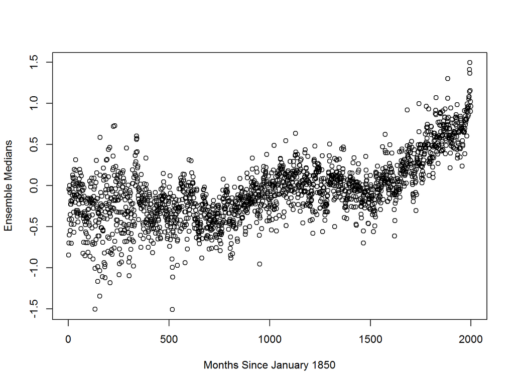

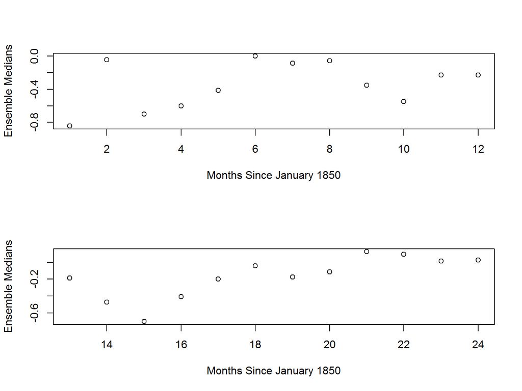

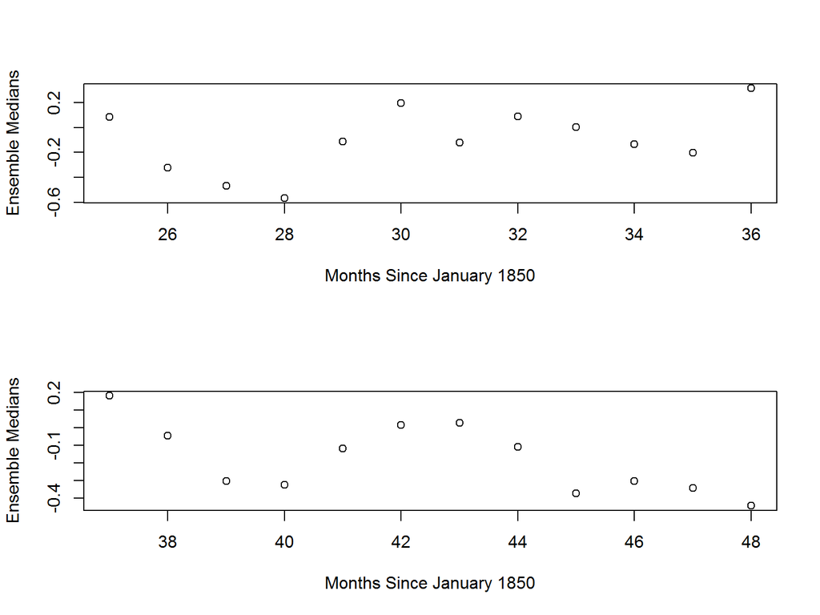

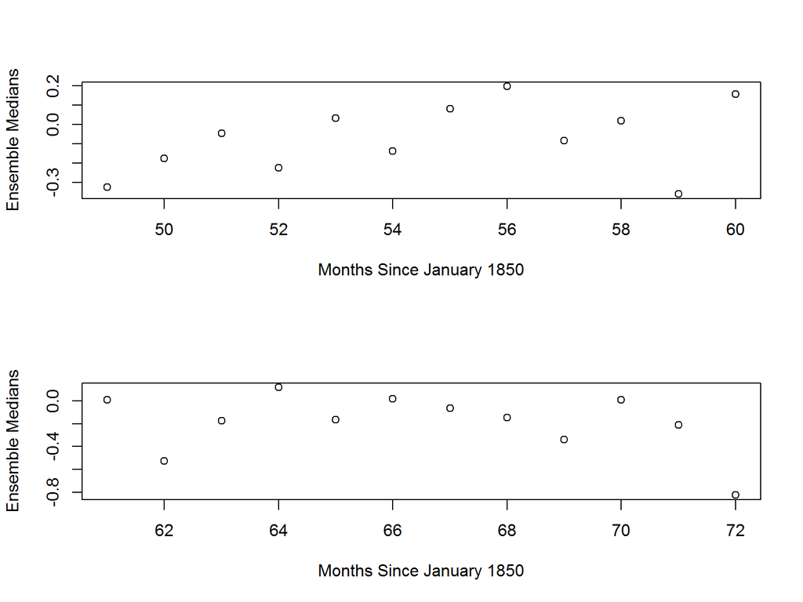

4) Our main focus with these data will be on estimating the long-term trend, starting with polynomial trend models. But first, check for seasonality in a model that accounts for a linear time trend. Use our previous fractional year for the trend. Report an `effects` plot and a test for the month model component.

$H_{o}$: all $\beta_{month i}$ = 0

$H_{a}$: at least one $\beta_{month i} \neq$ 0

_Based on an F-stat of 6.74 on 11 and 1986 degrees of freedom, using type II sums of squares, with an associated pvalue of < 0.001, there is strong evidence that the true median ensemble changes by month after accounting for fractional date. Examining the effect plot for the monthly factor, we see seasonality in the ensemble medians with average ensemble medians decreasing in January to March, increasing until August, and then decreasing until November, where there is a slight increase again in December.__ IS THAT AFTER ACCOUNTING FOR YEAR.DATE?

**we can see there is very little overlap in the confidence intervals for the median ensemble estimate for many pairs of months, indicating time has an affect on the monthly median ensemble changes. WE SHOULD DISCUSS THIS INTERPRETATION**

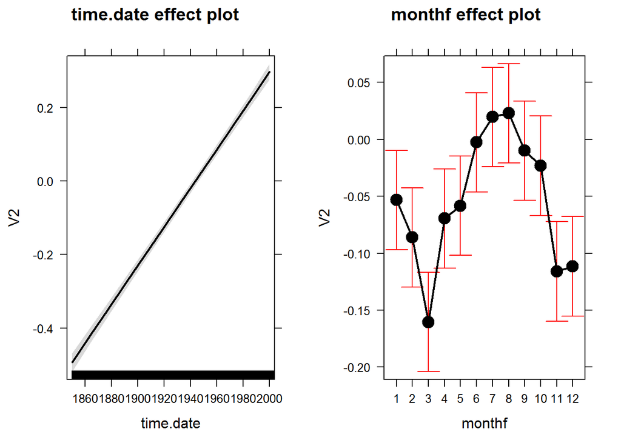

```r
hadcrut$monthf <- as.factor(as.numeric(substr(hadcrut$V1,6,7)))
hadcrut$time.date <- as.vector(time(hadcrut$date))
lm4 <- lm(V2 ~ time.date + monthf, data = hadcrut)#don't need monthf as explanatory bc month already induced in time??

plot(allEffects(lm4))
```

```r
lm4.anova <- Anova(lm4, type = "II")
(xtable(lm4.anova))
```

Note: when you use `time()` to generate the `Year` variable from a time series object it retains some time series object information that can cause conflicts later on. Create a new variable in your data.frame that uses something like `as.vector(time(tsdataname))`.

5. Check the residuals versus fitted values for any evidence of nonlinearity in the residuals vs fitted that was missed by the model with a linear trend and month component. Also note any potential issues with the constant variance assumption.

*Viewing the residuals vs. fitted values plot below, there appears to be a quadratice relationship between the fitted values and residuals that was not captured by the model. For fitted values less than -0.3, there appears to be more variation in the residuals than for fitted values above -0.3, indicating the constant variance assumption may be violated. The model is less accurately predicting median ensembles when the fitted median ensemble was below -0.3, which means that we may have left out a variable or structure that explains when median ensemble was lower than expected.*

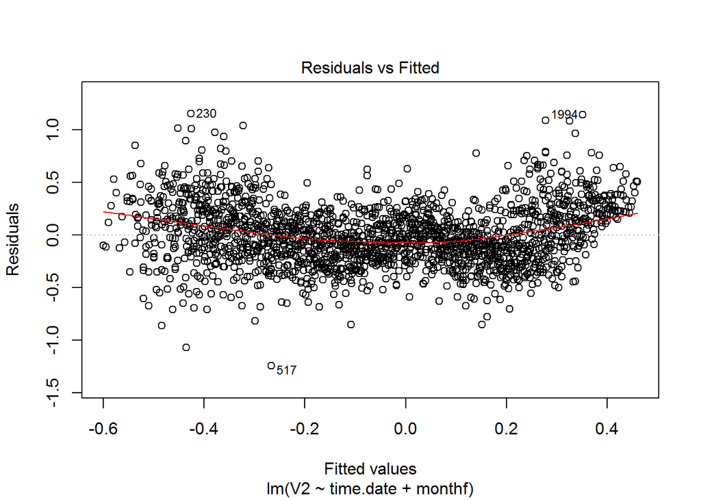

```r
par(mfrow = c(1,1))
plot(lm4,which=1)
```

6. You can add higher order polynomial terms to models using `x1+I(x1^2)+I(x1^3)`… or using the `poly` function, such as `poly(x1,3,raw=T)` for a cubic polynomial that includes the linear and quadratic components (we want this!). The `raw=T` keeps the variables in their raw or input format. Estimate the same model but now using polynomial trends that steps up from linear (poly(time,1,raw=T)) and stop when you get a failure to estimate a part of the model. Briefly discuss what happened.

When I got to the fifth degree polynomial, the estimate could not be computed. WHY? My guess is that it has something to do with the seasonality of the time.data variable, or it be perfectly collinear with another variable.

```r
lm.d1 <- lm(V2~poly(time.date,1,raw=TRUE) + monthf, data = hadcrut)
summary(lm.d1)
```

Call: lm(formula = V2 ~ poly(time.date, 1, raw = TRUE) + monthf, data = hadcrut)

Residuals: Min 1Q Median 3Q Max -1.24294 -0.19385 -0.02191 0.18118 1.15426

Coefficients: Estimate Std. Error t value Pr(>|t|) (Intercept) -1.027e+01 2.590e-01 -39.654 < 2e-16 poly(time.date, 1, raw = TRUE) 5.285e-03 1.335e-04 39.588 < 2e-16 monthf2 -3.281e-02 3.141e-02 -1.045 0.296288 monthf3 -1.072e-01 3.141e-02 -3.413 0.000656 monthf4 -1.621e-02 3.141e-02 -0.516 0.605890 monthf5 -5.031e-03 3.141e-02 -0.160 0.872754 monthf6 5.062e-02 3.141e-02 1.612 0.107154 monthf7 7.306e-02 3.141e-02 2.326 0.020102 monthf8 7.620e-02 3.145e-02 2.423 0.015502 monthf9 4.339e-02 3.145e-02 1.379 0.167953 monthf10 3.006e-02 3.145e-02 0.956 0.339359 monthf11 -6.260e-02 3.145e-02 -1.990 0.046701 monthf12 -5.818e-02 3.145e-02 -1.850 0.064507

Residual standard error: 0.287 on 1986 degrees of freedom Multiple R-squared: 0.4525, Adjusted R-squared: 0.4492 F-statistic: 136.8 on 12 and 1986 DF, p-value: < 2.2e-16

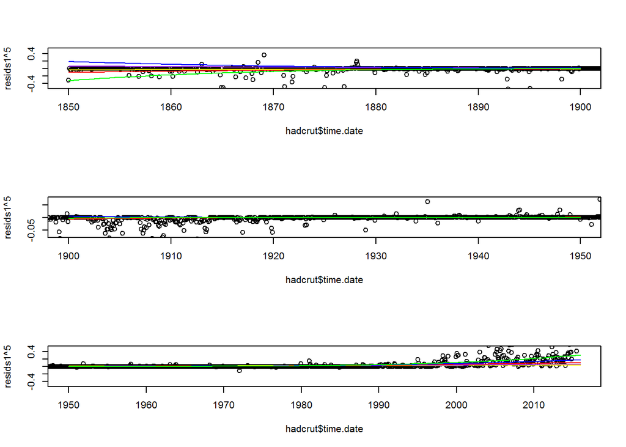

```r
test<-lm(V2~monthf,data=hadcrut)
resids1<-test$residuals
par(mfrow=c(3,1))

plot(resids1^5~hadcrut$time.date,xlim = c(1850,1900), ylim = c(-0.5,0.5))
curve((1/sd(hadcrut$time))*((x-mean(hadcrut$time))/sd(hadcrut$time)), add = TRUE, col = "yellow")
curve((1/sd(hadcrut$time))*((x-mean(hadcrut$time))/sd(hadcrut$time))^2, add = TRUE, col = "purple")
curve((1/sd(hadcrut$time))*((x-mean(hadcrut$time))/sd(hadcrut$time))^3, add = TRUE, col = "red")
curve((1/sd(hadcrut$time))*((x-mean(hadcrut$time))/sd(hadcrut$time))^4, add = TRUE, col = "blue")
curve((1/sd(hadcrut$time))*((x-mean(hadcrut$time))/sd(hadcrut$time))^5, add = TRUE, col = "green")

plot.window(xlim = c(1900,1950), ylim = c(-3,3))
plot(resids1^5~hadcrut$time.date,xlim = c(1900,1950), ylim = c(-0.075,0.075))
curve((1/sd(hadcrut$time))*((x-mean(hadcrut$time))/sd(hadcrut$time))^3, add = TRUE, col = "red")
curve((1/sd(hadcrut$time))*((x-mean(hadcrut$time))/sd(hadcrut$time))^4, add = TRUE, col = "blue")
curve((1/sd(hadcrut$time))*((x-mean(hadcrut$time))/sd(hadcrut$time))^5, add = TRUE, col = "green")

plot(resids1^5~hadcrut$time.date,xlim = c(1950,2016), ylim = c(-0.5,0.5))
curve((1/sd(hadcrut$time))*((x-mean(hadcrut$time))/sd(hadcrut$time)), add = TRUE, col = "yellow")
curve((1/sd(hadcrut$time))*((x-mean(hadcrut$time))/sd(hadcrut$time))^2, add = TRUE, col = "purple")
curve((1/sd(hadcrut$time))*((x-mean(hadcrut$time))/sd(hadcrut$time))^3, add = TRUE, col = "red")
curve((1/sd(hadcrut$time))*((x-mean(hadcrut$time))/sd(hadcrut$time))^4, add = TRUE, col = "blue")
curve((1/sd(hadcrut$time))*((x-mean(hadcrut$time))/sd(hadcrut$time))^5, add = TRUE, col = "green")
```

```r
lm.d <- NULL
for(i in 1:25){
lm.d[i] <- lm(V2~poly(time.date,i,raw=TRUE) + monthf, data = hadcrut)
}
```

[output not shown]

[output cut: 44 more lines]

[output not shown]

```r
lm.d[4]
```

[[1]] (Intercept) poly(time.date, i, raw = TRUE)1 2.146402e+05 -4.458441e+02 poly(time.date, i, raw = TRUE)2 poly(time.date, i, raw = TRUE)3 3.472438e-01 -1.201866e-04 poly(time.date, i, raw = TRUE)4 monthf2 1.559785e-08 -3.290620e-02 monthf3 monthf4 -1.073839e-01 -1.649884e-02 monthf5 monthf6 -5.424798e-03 5.012568e-02 monthf7 monthf8 7.245799e-02 7.885291e-02 monthf9 monthf10 4.594482e-02 3.252213e-02 monthf11 monthf12 -6.024048e-02 -5.592131e-02

```r
lm.d[5]
```

[[1]] (Intercept) poly(time.date, i, raw = TRUE)1 2.146402e+05 -4.458441e+02 poly(time.date, i, raw = TRUE)2 poly(time.date, i, raw = TRUE)3 3.472438e-01 -1.201866e-04 poly(time.date, i, raw = TRUE)4 poly(time.date, i, raw = TRUE)5 1.559785e-08 NA monthf2 monthf3 -3.290620e-02 -1.073839e-01 monthf4 monthf5 -1.649884e-02 -5.424798e-03 monthf6 monthf7 5.012568e-02 7.245799e-02 monthf8 monthf9 7.885291e-02 4.594482e-02 monthf10 monthf11 3.252213e-02 -6.024048e-02 monthf12 -5.592131e-02

```r
#another way, I was getting errors in 7 with the for loop
polyfunc<-function(i) {
  poly.lm<-lm(V2~poly(time.date,i,raw=TRUE) + monthf, data = hadcrut)
  return (summary(poly.lm))
}
polyfunc(4)
```

Call: lm(formula = V2 ~ poly(time.date, i, raw = TRUE) + monthf, data = hadcrut)

Residuals: Min 1Q Median 3Q Max -1.22122 -0.15262 -0.00671 0.14672 1.09471

Coefficients: Estimate Std. Error t value Pr(>|t|) (Intercept) 2.146e+05 2.102e+04 10.209 < 2e-16 poly(time.date, i, raw = TRUE)1 -4.458e+02 4.353e+01 -10.242 < 2e-16 poly(time.date, i, raw = TRUE)2 3.472e-01 3.379e-02 10.277 < 2e-16 poly(time.date, i, raw = TRUE)3 -1.202e-04 1.165e-05 -10.312 < 2e-16 poly(time.date, i, raw = TRUE)4 1.560e-08 1.507e-09 10.349 < 2e-16 monthf2 -3.291e-02 2.704e-02 -1.217 0.22376 monthf3 -1.074e-01 2.704e-02 -3.971 7.4e-05 monthf4 -1.650e-02 2.704e-02 -0.610 0.54181 monthf5 -5.425e-03 2.704e-02 -0.201 0.84101 monthf6 5.013e-02 2.704e-02 1.854 0.06392 monthf7 7.246e-02 2.704e-02 2.680 0.00743 monthf8 7.885e-02 2.708e-02 2.912 0.00363 monthf9 4.594e-02 2.708e-02 1.697 0.08993 monthf10 3.252e-02 2.708e-02 1.201 0.22992 monthf11 -6.024e-02 2.708e-02 -2.224 0.02623 monthf12 -5.592e-02 2.708e-02 -2.065 0.03905

Residual standard error: 0.2471 on 1983 degrees of freedom Multiple R-squared: 0.5948, Adjusted R-squared: 0.5918 F-statistic: 194.1 on 15 and 1983 DF, p-value: < 2.2e-16

```r
polyfunc(5)
```

Call: lm(formula = V2 ~ poly(time.date, i, raw = TRUE) + monthf, data = hadcrut)

Residuals: Min 1Q Median 3Q Max -1.22122 -0.15262 -0.00671 0.14672 1.09471

Coefficients: (1 not defined because of singularities) Estimate Std. Error t value Pr(>|t|) (Intercept) 2.146e+05 2.102e+04 10.209 < 2e-16 poly(time.date, i, raw = TRUE)1 -4.458e+02 4.353e+01 -10.242 < 2e-16 poly(time.date, i, raw = TRUE)2 3.472e-01 3.379e-02 10.277 < 2e-16 poly(time.date, i, raw = TRUE)3 -1.202e-04 1.165e-05 -10.312 < 2e-16 poly(time.date, i, raw = TRUE)4 1.560e-08 1.507e-09 10.349 < 2e-16 poly(time.date, i, raw = TRUE)5 NA NA NA NA monthf2 -3.291e-02 2.704e-02 -1.217 0.22376 monthf3 -1.074e-01 2.704e-02 -3.971 7.4e-05 monthf4 -1.650e-02 2.704e-02 -0.610 0.54181 monthf5 -5.425e-03 2.704e-02 -0.201 0.84101 monthf6 5.013e-02 2.704e-02 1.854 0.06392 monthf7 7.246e-02 2.704e-02 2.680 0.00743 monthf8 7.885e-02 2.708e-02 2.912 0.00363 monthf9 4.594e-02 2.708e-02 1.697 0.08993 monthf10 3.252e-02 2.708e-02 1.201 0.22992 monthf11 -6.024e-02 2.708e-02 -2.224 0.02623 monthf12 -5.592e-02 2.708e-02 -2.065 0.03905

Residual standard error: 0.2471 on 1983 degrees of freedom Multiple R-squared: 0.5948, Adjusted R-squared: 0.5918 F-statistic: 194.1 on 15 and 1983 DF, p-value: < 2.2e-16

7. If we center or, even better, make the polynomial functions orthogonal to one another, we can avoid the issue in the previous question. Use `poly(x1,?,raw=F)` and step up the polynomial order for time until the p-value for the last coefficient (use `summary()`) is “large”, reporting the single test result for each step in the building process. Then drop back one order and re-fit the model. Report the `effects` plot of the resulting model and describe the estimated trend. Note: aside from access to orthogonal polynomials the `poly` function interfaces with `Anova` and the `effects` package really nicely.

```r
hadcrut$time.date.scale <- c(scale(hadcrut$time.date))
a <- seq(1:15)
s <- lapply(a, function(x){summary(lm(V2~poly(time.date.scale,x,raw=FALSE) + monthf, data = hadcrut))})

a2 <- seq(2:15)
test <- NULL
for(i in a2){
test[i] <- cat("$H_{o}:$" ,"\beta",i-1, " = 0", "$H_{a}:$", "$\beta$", i, "$\neq 0$", "tstat = ", s[[i]]$coefficients[i,3], "df = ", 1987-i, "pvalue = ", s[[i]]$coefficients[i,4], "\\")
}
```

```r
#orthofunc<-function(i) {
  #ortho.lm<-lm(V2~poly(time.date,i,raw=FALSE) + monthf,data=hadcrut)
  #return (summary(ortho.lm))
#}
###orthofunc(10) #"large p value"

#final.lm<-lm(V2~poly(time.date,9,raw=FALSE) + monthf,data=hadcrut)
#plot(allEffects(final.lm))
```

8. Check the diagnostic plots from your final model. Does anything improve from the first version. Also plot the residuals vs time and compare that plot to residuals vs fitted.

```r
par(mfrow=c(2,2))
#plot(final.lm)
par(mfrow=c(2,1))
#plot(final.lm,which=1)
#plot(final.lm$residuals~hadcrut$time.date)
```

9. Run the following code so I can see what version of R you are now using:

### Documenting R version

```r
getRversion()
```

```
## [1] '3.3.1'
```